# Temporal Dynamics of Weather and Bike Usage in London: A Regression Analysis

Shivanshi Tiwari

## Question and Hypothesis

*What is the causal effect of feels like temperature on the shared bikes demand in London 2016?* *Are there other factors that also affect the decision of people using shared bikes?*

B1 = coefficient of feels-like temperature (t2)  
Null hypothesis H0: B1 = 0  
Alternative hypothesis HA: B1 ≠ 0

### Data description

- “cnt” - Count of new bike shares per hour
- “t1” - Real temperature in Celsius
- “t2” - “Feels like” temperature in Celsius
- “hum” - Humidity percentage.
- “wind_speed” - Wind speed in km/h.
- “is_holiday” - dummy field (1 for holiday, 0 for non-holiday)
- “is_weekend” - dummy field (1 if the day is a weekend, 0 otherwise)
- “non_workday”- dummy field (1 if the day is holiday or weekend, 0 otherwise)
- “daytime”- timestamp dummy field (1 if time during 6am to 6pm, 0 otherwise)
- “clear” - weather_code dummy field (1 for the day is clear, 0 for otherwise)
- “cloudy” - weather_code dummy field (1 for the day is cloudy, 0 for otherwise)
- “rainy” - weather_code dummy field (1 for the day is rainy, 0 for otherwise)
- “snowy_frosty” - weather_code dummy field (1 for the day is snowy or frosty, 0 for otherwise)
- “spring” - season dummy field (1 if the day is in spring, 0 otherwise)
- “summer” - season dummy field (1 if the day is in summer, 0 otherwise)
- “fall” - season dummy field (1 if the day is in fall, 0 otherwise)
- “winter” - season dummy field (1 if the day is in winter, 0 otherwise)

## Part 1: Descriptive statistics

```
Stats summary
======================================================
Statistic    N     Mean   Median St. Dev.  Min   Max
------------------------------------------------------
Real temp  8,699  12.38   12.00    5.89   -1.00 33.00
Feels temp 8,699  11.38   12.00    6.91   -5.00 32.50
Humidity   8,699  73.18   76.00   14.23   23.00 100.00
Wind speed 8,699  15.17   14.00    7.68   0.00  56.00
Bike count 8,699 1,164.45  862   1,107.05   9   5,422
------------------------------------------------------
```

Based on the table of descriptive statistics:

- The sample of 8,699 observations has an average real temperature at 12.38 Celsius degree, an average Feels like temperature at 11.38 Celsius degree, an average humidity level at 73.18%, an average wind speed of 15.17km/h, and average 1,164.45 sharing bikes per hour.
- Note that except for the bike count, the median and mean are quite close in other variables. Specifically, the median for real temperature, wind speed and bike count are lower than their mean, indicating that the distributions of these three variables are slightly positively skewed (right-skewed), while the median for Feels-like temperature and humidity are higher than their mean, indicating that the distributions of these two variables are negatively skewed (left-skewed).
- Eyeballing the standard deviation, we observe that there is a larger variation in humidity and a huge variation in bike count, indicating that the values are spread out over a large range from the mean in these two variables. For all the other three variables with smaller standard deviation, the sample variation around mean is rather small.

Simultaneously, we notice that there is no identical statistical difference between real temperature(t1) and feels like temperature(t2), but the two variables are strongly correlated and we should only include one of them in analysis. Since the primary interest in this study is exploring factors that affect the decision of people using shared bikes, how people perceive and respond to the weather, then “Feels like temperature” could be more relevant than the real monitored temperature. **We then decide to adopt t2 as our variable of interest.**

Now we explore whether there is a relationship between feels-like temperature and shared bike counts by plotting in graph:

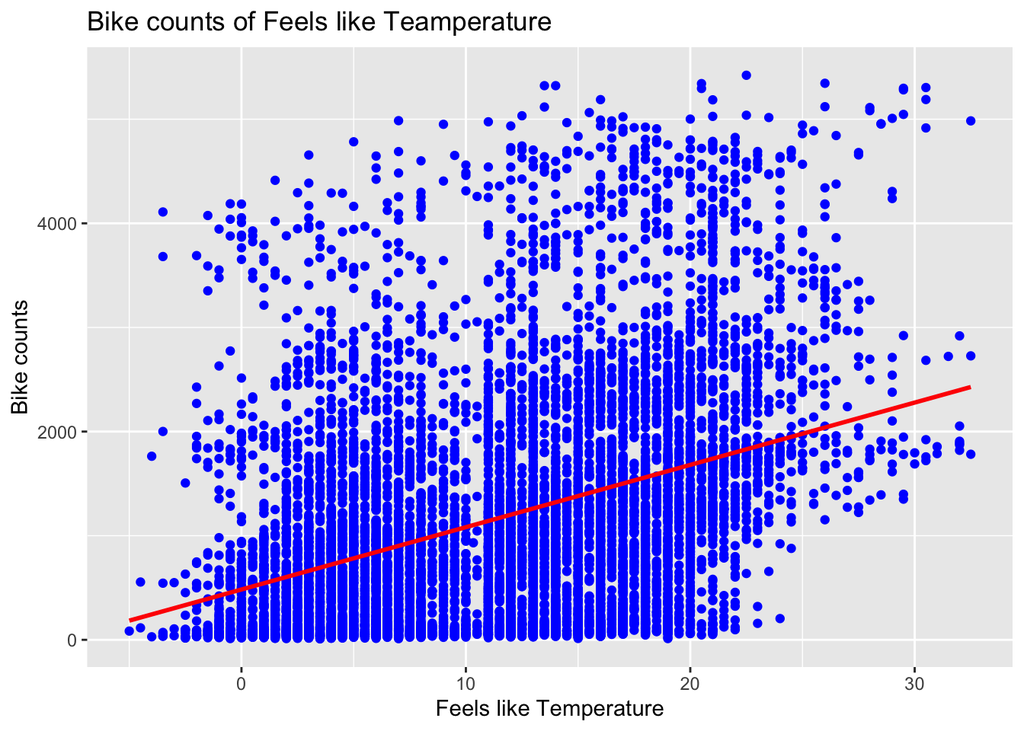

From the scatterplot, it shows that there is a **positive relationship** between shared bike demand and feels like temperature. Since as feels like temperature increases, the dots appear more towards upper-right side, indicating that the shared bike count also increases. We also observed that there is no eye-catching outlier in the sample.

## Part 2: Baseline Regression Analysis

**Control variables**

Initially, we identified other potential variables that might influence the shared bike count within the London market, considering two primary dimensions: **weather conditions** and **time**. Specifically, we selected two continuous variables, *humidity* and *wind_speed*, to account for fundamental weather factors. We also incorporated dummy variables based on timestamp—such as *non_workday* and *daytime*—to investigate potential time patterns affecting shared bike demand. Additionally, we created more dummies—*clear*, *cloudy*, *rainy*, and *snowy_frosty*—based on distinct weather categories to capture nuanced variations. Based on *feels like temperature(t2)*, our variable of interest, we then included these control variables in regression one by one.

```
Linear & Polynomial regression of shared bike counts on different factors
=============================================================================================================
                                                       Dependent variable:
                    -----------------------------------------------------------------------------------------
                                                               cnt
                       (1)       (2)       (3)       (4)       (5)       (6)       (7)       (8)       (9)
-------------------------------------------------------------------------------------------------------------
t2                   59.835    36.090    36.161    36.063    35.149    35.592    35.549     2.653    -4.369
                     (1.656)   (1.611)   (1.611)   (1.603)   (1.511)   (1.527)   (1.528)   (1.656)   (1.611)

t2sq                                                                                        1.447     2.148


t2cub                                                                                                -0.018


hum                            -28.854   -28.636   -28.273   -22.113   -20.883   -20.838   -19.549   -19.617
                               (0.756)   (0.785)   (0.793)   (0.832)   (0.897)   (0.900)             (0.756)

wind_speed                                1.437     2.182    -3.740    -2.300    -2.233    -1.999    -2.045
                                         (1.299)   (1.292)   (1.241)   (1.300)   (1.306)

non_workday                                       -225.882  -229.767  -227.719  -227.243  -224.333  -224.294
                                                  (18.481)  (17.078)  (17.081)  (17.081)

daytime                                                      748.767   750.173   750.159   745.335   745.799
                                                            (21.757)  (22.767)  (22.765)

cloudy                                                                  3.013     1.452    23.905    23.931
                                                                      (22.977)  (23.131)

rainy                                                                 -180.031  -182.136  -159.501  -157.976
                                                                      (29.392)  (29.601)

snowy_frosty                                                                    -139.667  -198.630  -200.373
                                                                                (58.620)

Constant             483.369  2,865.212 2,826.609 2,859.500 2,135.297 2,037.028 2,034.552 2,041.858 2,060.290
                    (19.475)  (64.053)  (73.780)  (74.022)  (76.843)  (80.587)  (80.744)  (19.475)  (64.053)

-------------------------------------------------------------------------------------------------------------
Observations          8,699     8,699     8,699     8,699     8,699     8,699     8,699     8,699     8,699
R2                    0.139     0.255     0.255     0.264     0.368     0.371     0.371     0.375     0.375
Adjusted R2           0.139     0.255     0.255     0.264     0.368     0.370     0.370     0.374     0.374
Residual Std. Error 1,027.026  955.635   955.631   950.000   880.184   878.469   878.487   875.600   875.607
F Statistic         1,409.314 1,488.353  992.604   779.401  1,013.338  731.783   640.364   579.461   521.592
=============================================================================================================
Note:                                                                                                      NA
```

```
Linear hypothesis test

Hypothesis:
t2sq = 0
t2cub = 0

Model 1: restricted model
Model 2: cnt ~ t2 + t2sq + t2cub + hum + wind_speed + non_workday + daytime +
    cloudy + rainy + snowy_frosty

Note: Coefficient covariance matrix supplied.

  Res.Df Df      F    Pr(>F)
1   8690
2   8688  2 26.185 4.595e-12 ***
---
Signif. codes:  0 '***' 0.001 '**' 0.01 '*' 0.05 '.' 0.1 ' ' 1
```

```
Linear hypothesis test

Hypothesis:
t2cub = 0

Model 1: restricted model
Model 2: cnt ~ t2 + t2sq + t2cub + hum + wind_speed + non_workday + daytime +
    cloudy + rainy + snowy_frosty

Note: Coefficient covariance matrix supplied.

  Res.Df Df     F Pr(>F)
1   8689
2   8688  1 0.514 0.4734
```

**Omitted Variable Bias**

- As shown in the regression table, by adding variables *humidity*, *wind_speed* and *non_workday*, the estimation coefficient of t2 drop from 59.835 to around 36.1, indicating that model (1) suffers from upward omitted variable bias. Also in model (1), with R-square 0f 0.139, variable t2 solely explains only 13.9% of the sample variation of the regression. Therefore, we drop simple linear regression model (1).
- By continue adding variable *daytime*, we observe that the coefficient estimate of *t2* has decrease from 36.063 to 35.149, indicating that model (4) still suffers from upward omitted variable bias.The adjusted R-square improved from 0.264 to 0.368, meaning that the multiple linear regression model(5) has reached a better fit.
- However, comparing model(5) and model(6/7), by adding more variables describing different weather type: *cloudy*, *rainy* and *snowy_frosty*, the coefficient estimate of *t2* fluctuates subtly and tends to be stable around 35.6. We observe a slightly downward omitted variable bias in model(5), and a higher adjusted R-square of 0.37 in model(7)

**Statistic significance and sign of control variables**

- *humidity*: the coefficient estimation of *hum* has t-stat > 1.96 throughout all regression models, meaning we are able to reject the null and proof the estimation statistically significant. The negative sign is align with expectation, as we assume that with humidity increases, the cycling environment (e.g road condition) will get wetter, discouraging people to ride shared bikes. Meanwhile, by adding other variables in model(6&7), the coefficient estimation of hum tends to be stable at -20.8, avoiding omitted variable bias.
- *wind_speed*: in model(3&4), the coefficient estimation of *wind_speed* has t-stat 1.1 and 1.68, both < 1.96 and we fail to reject the null. However, by adding rainy and snowy_frosty to the regression, the coefficient estimations on wind_speed in model (5) are having t-stat > 1.96, suggesting proof of the estimation statistically significant. However, in model (6&7), the estimation of wind_speed became statistically insignificant again. Noted that there is a sign change from positive to negative from model (4) to (5-7), and a negative sign is align with our expectation. Intuitively, with a higher wind speed, people will feel harder to ride a bike.
- *non_workday*: the coefficient estimation of *non_workday* has t-stat > 1.96 throughout all regression models, meaning we are able to reject the null and proof the estimation statistically significant. The negative sign is align with expectation, as we assume that with people tends to ride shared bikes less during holiday and weekend, since they use such transportation for work.
- *daytime*: the coefficient estimation of *daytime* has t-stat > 1.96 in model(5-7), meaning we are able to reject the null and proof the estimation statistically significant.The positive sign is expected, since we assume that people use shared bikes to commute from home to work. From the regressions, we observe that the shared bike count is higher when it is during 6am to 6pm than other time.
- *cloudy*: the coefficient estimation of *cloudy* has t-stat < 1.96 in model (7&8), proofing the coefficient statistically insignificant. We observe an upward omitted variable bias in model (6) when not including other variables in the same weather category.
- *rainy*: the coefficient estimation of *rainy* has t-stat > 1.96 in model(6&7), meaning we are able to reject the null and proof the estimation statistically significant.The negative sign is expected, as we assume that when it is rainy, it will discourage people to ride shared bikes, and the share bike count per hour will be less than when it does not rain.
- *snowy_frosty*: the coefficient estimation of *snowy_frosty* has t-stat > 1.96 in model(7), meaning we are able to reject the null and proof the estimation statistically significant.The negative sign is align with expectation, as we assume that when it is snowy or frosty, it will discourage people to ride shared bikes, and the share bike count per hour will be less than when it does not snow or frost.

**Measure of fit in multiple linear regressions**

- We observe from the regression table that in model(7), the adjusted R-square is 0.370, meaning that *t2*, *hum*, *wind_speed*, *non_workday*, *daytime*, *cloudy*, *rainy*, *snowy_frosty* together explain 37% of the sample variation of the regression.
- However, recall for the scatterplot of *t2* and *cnt*, we notice the probability of non-linear relationship between these two variables. Therefore, we continue to explore non-linear regressions for a better fit.

**Polynomials vs Linear**

We then build **quadratic** and **cubic** form of *t2*, as *t2sq*, *t2cub* and run polynomial regressions based on model(7). From the regression table, we notice obvious change of coefficient estimation of *t2* in model (8&9).

**Logarithm vs Linear**

Since shared bike count is a non-zero positive variable and the distribution of it is right-skewed, we take the natural log of a cnt as lcnt in regression.

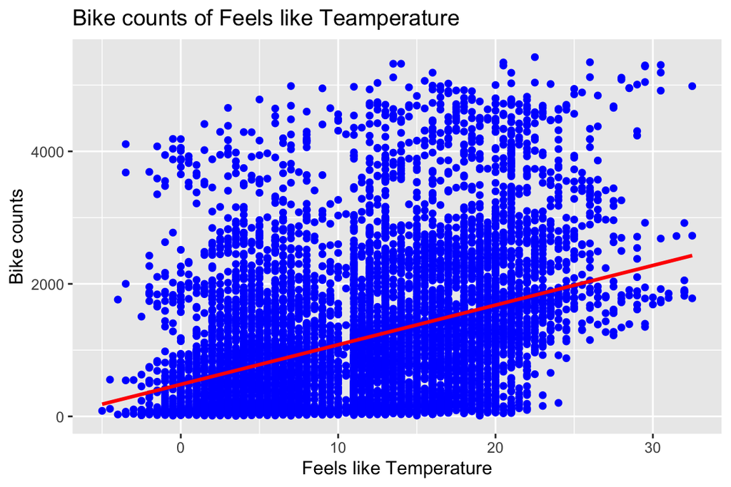

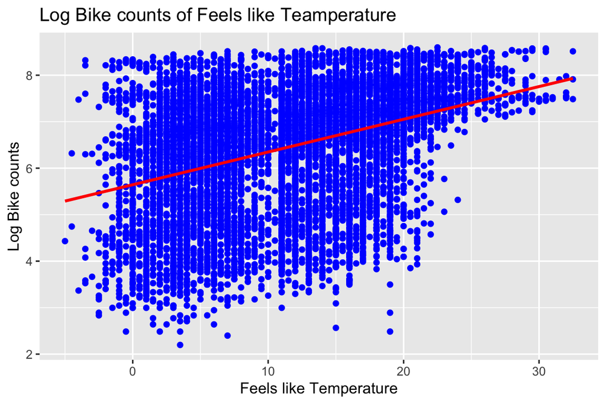

We first plot the graph of lcnt of t2, the regression line fits better surrounded by sample dots compared to linear model.

```
Log-Linear regression of shared bike counts with interaction terms
===============================================================================================
                                                Dependent variable:
                    ---------------------------------------------------------------------------
                       cnt                                  lcnt
                       (1)      (2)     (3)      (4)     (5)     (6)     (7)     (8)     (9)
-----------------------------------------------------------------------------------------------
t2                   35.549    0.038   0.028    0.032   0.064   0.039   0.038   0.039   0.041
                     (1.528)  (0.002) (0.004)  (0.002) (0.003) (0.002) (0.002) (0.002) (0.004)

hum                  -20.838  -0.026   -0.026  -0.026  -0.027  -0.026  -0.026  -0.024   -0.026
                     (0.900)  (0.001) (0.001)  (0.001) (0.001) (0.001) (0.001) (0.001) (0.001)

wind_speed           -2.233   -0.002   -0.009  -0.002  -0.003  -0.002  -0.002  -0.002   -0.016
                     (1.306)  (0.001) (0.003)  (0.001) (0.001) (0.001) (0.001) (0.001) (0.003)

non_workday         -227.243  -0.092   -0.094  -0.350  -0.095  -0.092  -0.092  -0.092   -0.333
                    (17.081)  (0.020) (0.020)  (0.041) (0.020) (0.020) (0.020) (0.020) (0.041)

daytime              750.159   1.134   1.132    1.136   1.687   1.133   1.133   1.133   1.721
                    (22.765)  (0.023) (0.023)  (0.023) (0.042) (0.023) (0.023) (0.023) (0.042)

cloudy                1.452    0.101   0.103    0.094   0.098   0.111   0.101   0.096   0.091
                    (23.131)  (0.025) (0.025)  (0.025) (0.024) (0.045) (0.025) (0.025) (0.024)

rainy               -182.136  -0.132   -0.120  -0.128  -0.116  -0.132  -0.133   1.171   1.048
                    (29.601)  (0.039) (0.039)  (0.039) (0.039) (0.039) (0.039) (0.228) (0.232)

snowy_frosty        -139.667  -1.273   -1.262  -1.220  -1.143  -1.270  -1.111  -1.290   -1.080
                    (58.620)  (0.190) (0.189)  (0.195) (0.193) (0.190) (0.205) (0.190) (0.198)

t2_wind_speed                          0.001                                            0.001
                                      (0.0002)                                         (0.0002)

t2_non_workday                                  0.023                                   0.021
                                               (0.003)                                 (0.003)

t2_daytime                                             -0.049                           -0.052
                                                       (0.003)                         (0.003)

t2_cloudy                                                      -0.001
                                                               (0.003)

t2_snowy_frosty                                                        -0.060
                                                                       (0.068)

hum_rainy                                                                      -0.016   -0.014
                                                                               (0.003) (0.003)

Constant            2,034.552  7.336   7.460    7.420   7.183   7.330   7.334   7.244   7.395
                    (80.744)  (0.081) (0.092)  (0.082) (0.082) (0.085) (0.081) (0.082) (0.093)

-----------------------------------------------------------------------------------------------
Observations          8,699    8,699   8,699    8,699   8,699   8,699   8,699   8,699   8,699
R2                    0.371    0.466   0.466    0.469   0.482   0.466   0.466   0.467   0.489
Adjusted R2           0.370    0.465   0.466    0.468   0.482   0.465   0.465   0.467   0.488
Residual Std. Error  878.487   0.951   0.951    0.948   0.936   0.951   0.951   0.950   0.930
F Statistic          640.364  946.526 843.486  851.627 899.319 841.277 841.426 847.157 692.182
===============================================================================================
Note:                                                                                        NA
```

We then run log-linear regression including 8 variables. Note that model (1) here is linear model (7) in previous regression table.

From the regression table, we observe that:

- Similar to multiple linear regression, *t2*, *hum*, *non_workday*, *daytime*, *rainy* and *snowy_frosty* all have t-stat > 1.96, indicating the coefficient estimation to be statistically significant. There sign of each variable is also the same in the log-linear formation as that in linear regression model(1).
- Different from linear regression, t-stat of *wind_speed* in model(2) is > 1.96, suggesting that we are able reject the null and the coefficient estimation of *wind_speed* is statistically significant.
- Different from linear regression, *cloudy* appears to have a t-stat > 1.96 in model (2), indicating the coefficient estimation of *cloudy* to be statistically significant.The positive sign is reasonable. Since cloudy day is not too hot and the road condition is not wet or slippery (when assuming the weather is not rainy or snowy/frosty). We therefore assume that people will drive more shared bikes during a cloudy day.
- Measure of fit: we observe that in log-linear regression model (2), the adjusted R-square is 0.465, indicating that *t2*, *hum*, *wind_speed*, *non_workday*, *daytime*, *cloudy*, *rainy* and *snowy_frosty* together explains 46.5% of the sample variation of the log-linear regression.

Based on all the analysis above, we can now decide our log-linear model(2) as our baseline regression:

*log(cnt) = 0.038 * t2 - 0.026 * hum - 0.002 * wind_speed -0.092 * non_workday + 1.134 * daytime + 0.101 * cloudy - 0.132 * rainy - 1.273 * snowy_frosty*

## Part3: Alternative Regression Specification

In order to explore whether the effect of *t2* on shared bike counts vary from other conditions, we created interaction terms: *t2_wind_speed*, *t2_non_workday*, *t2_daytime*, *t2_cloudy*, *t2_snowy_frosty*, *hum_rainy*. The interaction models in above table allows the effect of *feels-like temperature(t2)* on *shared bike count(cnt)* to vary with continuous variable *wind_speed*, and dummy variables *non_workday*, *day_time*, *cloudy* and *snowy_frosty*. It also allows the effect of *hum* on shared bike count to vary with dummy variable *rainy*. We now explore specific questions by interpreting the regressions with interaction terms.

```
Linear hypothesis test

Hypothesis:
t2 = 0
t2_wind_speed = 0

Model 1: restricted model
Model 2: lcnt ~ t2 + hum + wind_speed + non_workday + daytime + cloudy +
    rainy + snowy_frosty + t2_wind_speed

Note: Coefficient covariance matrix supplied.

  Res.Df Df      F    Pr(>F)
1   8691
2   8689  2 291.21 < 2.2e-16 ***
---
Signif. codes:  0 '***' 0.001 '**' 0.01 '*' 0.05 '.' 0.1 ' ' 1
```

```
Linear hypothesis test

Hypothesis:
t2 = 0
t2_non_workday = 0

Model 1: restricted model
Model 2: lcnt ~ t2 + hum + wind_speed + non_workday + daytime + cloudy +
    rainy + snowy_frosty + t2_non_workday

Note: Coefficient covariance matrix supplied.

  Res.Df Df      F    Pr(>F)
1   8691
2   8689  2 378.45 < 2.2e-16 ***
---
Signif. codes:  0 '***' 0.001 '**' 0.01 '*' 0.05 '.' 0.1 ' ' 1
```

```
Linear hypothesis test

Hypothesis:
t2 = 0
t2_daytime = 0

Model 1: restricted model
Model 2: lcnt ~ t2 + hum + wind_speed + non_workday + daytime + cloudy +
    rainy + snowy_frosty + t2_daytime

Note: Coefficient covariance matrix supplied.

  Res.Df Df      F    Pr(>F)
1   8691
2   8689  2 330.94 < 2.2e-16 ***
---
Signif. codes:  0 '***' 0.001 '**' 0.01 '*' 0.05 '.' 0.1 ' ' 1
```

```
Linear hypothesis test

Hypothesis:
t2 = 0
t2_cloudy = 0

Model 1: restricted model
Model 2: lcnt ~ t2 + hum + wind_speed + non_workday + daytime + cloudy +
    rainy + snowy_frosty + t2_cloudy

Note: Coefficient covariance matrix supplied.

  Res.Df Df      F    Pr(>F)
1   8691
2   8689  2 277.06 < 2.2e-16 ***
---
Signif. codes:  0 '***' 0.001 '**' 0.01 '*' 0.05 '.' 0.1 ' ' 1
```

```
Linear hypothesis test

Hypothesis:
t2 = 0
t2_snowy_frosty = 0

Model 1: restricted model
Model 2: lcnt ~ t2 + hum + wind_speed + non_workday + daytime + cloudy +
    rainy + snowy_frosty + t2_snowy_frosty

Note: Coefficient covariance matrix supplied.

  Res.Df Df      F    Pr(>F)
1   8691
2   8689  2 275.98 < 2.2e-16 ***
---
Signif. codes:  0 '***' 0.001 '**' 0.01 '*' 0.05 '.' 0.1 ' ' 1
```

```
Linear hypothesis test

Hypothesis:
hum = 0
hum_rainy = 0

Model 1: restricted model
Model 2: lcnt ~ t2 + hum + wind_speed + non_workday + daytime + cloudy +
    rainy + snowy_frosty + hum_rainy

Note: Coefficient covariance matrix supplied.

  Res.Df Df     F    Pr(>F)
1   8691
2   8689  2 465.6 < 2.2e-16 ***
---
Signif. codes:  0 '***' 0.001 '**' 0.01 '*' 0.05 '.' 0.1 ' ' 1
```

**Q1: Does the effect of feels-like temperature on new shared bike counts depend on wind speed?**

**Q5: Additionally, since intuitively humidity might related to rain, we also try to explore does the effect of humidity on new shared bike counts depend on whether it is rainy?**

## Part 4: Conclusion

### Limitation

**Internal Validity**

- Sampling selection bias Data Reliability: there might be possible inconsistencies or errors in recollection in survey which could influence the study’s outcomes( people’s answer to feels-like temperature)
- Reverse Causality: This consideration is unlikely to occur in our data given the shared bike demand generally does not influence temperature, time or any natural weather conditions.
- Omitted Variable Bias: our model stabilizes in log-linear model (2) after we add on additional control variables (i.e. non_workday, daytime, cloudy, rainy etc.) to our variable of interest, Feels-like temperature(t2). Our baseline model has avoided to suffer from much omitted variable bias. However, there is potential overlook of influential factors like socioeconomic status or specific urban infrastructure. May impact the accuracy of causal relationships derived from the analysis.

**External Validity**

- Generalizability Constraints: our findings are tailored to London’s urban environment in 2016, limiting applicability to other cities or time periods. Variations in environmental, cultural, and infrastructural aspects can affect the relevance of results elsewhere. The results may not accurately represent bike sharing dynamics in differing urban settings or future scenarios.